# Kapitał społeczny - poprawione skale

Szymon Talaga

16.12.2014

Raport przedstawia drugie podejście do skalowania kapitału społecznego. Zmiana strategii skalowania została wymuszona tym, że otrzymane skale, choć dobrej jakości pod względem zgodności z modelem mokkena, były obciążone bardzo poważną skazą - były zbyt łatwe i nie dyskryminowały między osobami o wysokim kapitale. Dlatego zastosowano trochę inne podejście, ale oparte na wynikach pierwszej procedury skalowania, które ma temu zaradzić.

Jako punkt wyjścia przyjęto dokonane w poprzedniej analizie spostrzeżenie, że baterie pytań scknow i schelp odpowiadają innym wymiarom kapitału społecznego. Dlatego tym razem zostały wyodrębnione najlepsze skale w obrębie obu baterii, w których skład wchodziły tylko pytania o wyższym poziomie trudności. Dokładniej rzecz biorąc uwzględnione jedynie pozycje o średnich mniejszych bądź równych 3. Dzięki temu możliwe było wyłonienie skal o większej mocy dyskryminacyjnej.

Wczytanie niezbędnych pakietów, funkcji i danych:

```r
library(mokken)
library(lattice)
library(knitr)
source("../Scaling/scaling-Helper.R")
source("../HelperFunctionsMisc/ComputingMisc.R")
load("../Scaling/Scal-ResGenAll.RData") # Wykorzystana zostaje przestrzeń zmiennych z poprzedniej analizy
load("../MainData/MainData10.RData")
D10 = D
```

## Skalowanie mobilizacji zasobów (resmob)

Wybór i ograniczenie zbioru zmiennych tylko do tych, których średnie są mniejsze bądź równe 3:

```r
D.help = D.back[, grep('schelp', names(D.back))]
diffs.help = apply(D.help, 2, mean)
D.hdiff = D.help[, names(diffs.help)[diffs.help <= 3]]
```

**Skalowanie**

Automatyczny dobór pozycji o wystaczająco dobrych współczynnikach skalowania w oparciu algorytm genetyczny:

```r
scale.ga.hdiff = aisp(D.hdiff, search="ga", lowerbound=.35)
kable(scale.ga.hdiff)
```

|  | Scale |
| --- | --- |
| schelp4 | 1 |
| schelp6 | 1 |
| schelp7 | 0 |
| schelp10 | 1 |
| schelp14 | 1 |

Ograniczenie zbioru zmiennych do najlepszej skali (skala 1):

```r
D.hdiff = D.hdiff[, rownames(scale.ga.hdiff)[scale.ga.hdiff[,1] == 1]]
```

Jak widać pytania które pozostały odnoszą się do pomocy w zakresie: porady prawnej (4); załatwienia pracy dorywczej (6); napisania dobrych referencji (10); pożyczki większej sumy pieniędzy (14). Ten zestaw pytań jest o tyle dobry, że faktycznie odnosi się tylko i wyłącznie do dosyć specyficznych, i bardzo przydatnych, form pomocy, dzięki czemu, ma szanse faktycznie rożnicować osoby badane.

Homogeniczna monotoniczność:

```r
mono.hdiff = check.monotonicity(D.hdiff)
kable(summary(mono.hdiff))
```

|  | ItemH | #ac | #vi | #vi/#ac | maxvi | sum | sum/#ac | zmax | #zsig | crit |
| --- | --- | --- | --- | --- | --- | --- | --- | --- | --- | --- |
| schelp4 | 0.40 | 4 | 0 | 0 | 0 | 0 | 0 | 0 | 0 | 0 |
| schelp6 | 0.43 | 4 | 0 | 0 | 0 | 0 | 0 | 0 | 0 | 0 |
| schelp10 | 0.45 | 4 | 0 | 0 | 0 | 0 | 0 | 0 | 0 | 0 |
| schelp14 | 0.38 | 4 | 0 | 0 | 0 | 0 | 0 | 0 | 0 | 0 |

Widać, że dane dobrze odpowiadają założeniu homogenicznej monotoniczności.

Podwójna monotoniczność:

```r
iio.hdiff = check.iio(D.hdiff) # Metoda niezmiennej kolejności pozycji
kable(summary(iio.hdiff)$item.summary)
```

|  | ItemH | #ac | #vi | #vi/#ac | maxvi | sum | sum/#ac | tmax | #tsig | crit |
| --- | --- | --- | --- | --- | --- | --- | --- | --- | --- | --- |
| schelp14 | 0.38 | 3 | 0 | 0 | 0 | 0 | 0 | 0 | 0 | 0 |
| schelp6 | 0.43 | 3 | 0 | 0 | 0 | 0 | 0 | 0 | 0 | 0 |
| schelp4 | 0.40 | 3 | 0 | 0 | 0 | 0 | 0 | 0 | 0 | 0 |
| schelp10 | 0.45 | 3 | 0 | 0 | 0 | 0 | 0 | 0 | 0 | 0 |

Wyniki analizy pokazują, że dane są dobrze dopasowane również do założenia podwójnej monotoniczności.

Globalny współczynnik skalowania:

```r
H.hdiff = coefH(D.hdiff)
```

Globalny współczynnik skalowania $H$ wyniósł 0,413 z 95% przedziałem ufności równym [0.33068, 0.49532]. Można to uznać za satysfakcjonującą dobroć dopasowania.

Rzetelność:

```r
Rel.hdiff = check.reliability(D.hdiff, LCRC = TRUE)
```

Rzetelnośc mierzona współczynnikiem $\alpha$-Cronbacha wyniosła 0,71. Metoda LCRC dała taki sam wynik. Oznacza to, że skala ma wystarczający poziom precyzji pomiaru, chociaż zdecydowanie nie jest on idealny.

Jednakże bezsprzeczną przewagę tego podejścia pokazuje prosty histogram:

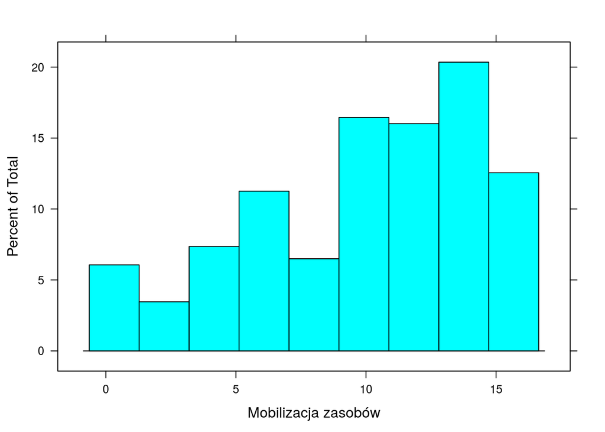

```r
resmob = apply(D.hdiff, 1, sum)
histogram(resmob, xlab="Mobilizacja zasobów")
```

Jak widać jest on o wiele mniej lewoskośny od rozkładu poprzedniej skali:

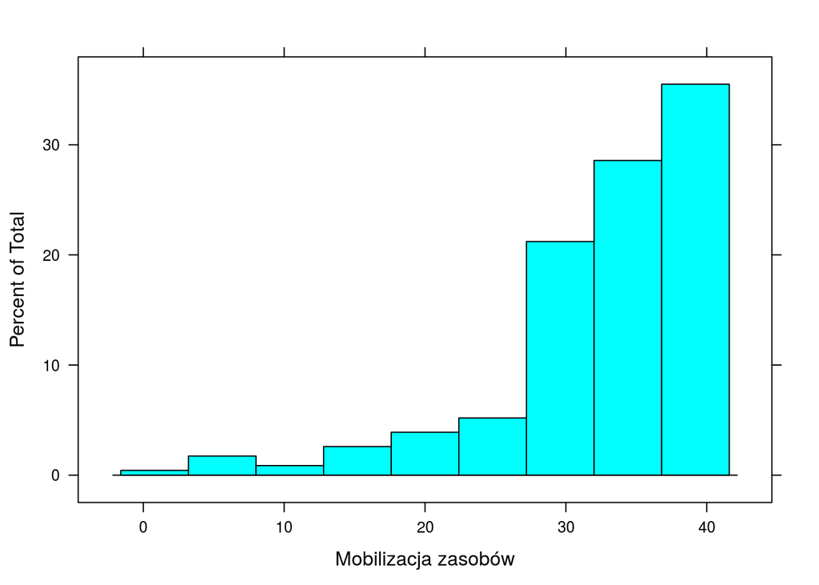

```r
histogram(~ resmob, data=D10, xlab="Mobilizacja zasobów")
```

## Skalowanie kontaktów społecznych

Wybór i ograniczenie zbioru zmiennych tylko do tych, których średnie są mniejsze bądź równe 3:

```r
D.kdiff = D.back[, grep("scknow", names(D.back))]
diff.know = apply(D.kdiff, 2, mean)
D.kdiff = D.kdiff[, names(diff.know)[diff.know <= 3]]
```

**Skalowanie**

Automatyczny dobór pozycji o wystaczająco dobrych współczynnikach skalowania w oparciu algorytm genetyczny:

```r
scale.ga.kdiff = aisp(D.kdiff, search="ga", lowerbound=.35)
D.kdiff = D.kdiff[, rownames(scale.ga.kdiff)[scale.ga.kdiff[,1]==1]]
```

Homogeniczna monotoniczność:

```r
mono.kdiff = check.monotonicity(D.kdiff)
kable(summary(mono.kdiff))
```

|  | ItemH | #ac | #vi | #vi/#ac | maxvi | sum | sum/#ac | zmax | #zsig | crit |
| --- | --- | --- | --- | --- | --- | --- | --- | --- | --- | --- |
| scknow3 | 0.49 | 4 | 0 | 0 | 0 | 0 | 0 | 0 | 0 | 0 |
| scknow5 | 0.41 | 4 | 0 | 0 | 0 | 0 | 0 | 0 | 0 | 0 |
| scknow13 | 0.39 | 4 | 0 | 0 | 0 | 0 | 0 | 0 | 0 | 0 |
| scknow14 | 0.40 | 4 | 0 | 0 | 0 | 0 | 0 | 0 | 0 | 0 |

Dane są wysoce zgodne z modelem homogenicznej monotoniczności.

Podwójna monotoniczność:

```r
iio.kdiff = check.iio(D.kdiff)
kable(summary(iio.kdiff)$item.summary)
```

|  | ItemH | #ac | #vi | #vi/#ac | maxvi | sum | sum/#ac | tmax | #tsig | crit |
| --- | --- | --- | --- | --- | --- | --- | --- | --- | --- | --- |
| scknow13 | 0.39 | 3 | 0 | 0 | 0 | 0 | 0 | 0 | 0 | 0 |
| scknow5 | 0.41 | 3 | 0 | 0 | 0 | 0 | 0 | 0 | 0 | 0 |
| scknow3 | 0.50 | 3 | 0 | 0 | 0 | 0 | 0 | 0 | 0 | 0 |
| scknow14 | 0.40 | 3 | 0 | 0 | 0 | 0 | 0 | 0 | 0 | 0 |

Widać, że występuje również pełna zgodność z modelem podwójnej homogeniczności.

Globalny współczynnik skalowania:

```r
H.kdiff = coefH(D.kdiff)
```

Rzetelność:

```r
Rel.kdiff = check.reliability(D.kdiff, LCRC = TRUE)
```

Niemniej jednak skala ta ma wielką zaletą, jaką jest lepszy potencjał dyskryminacyjny, co widać po jej rozkładzie:

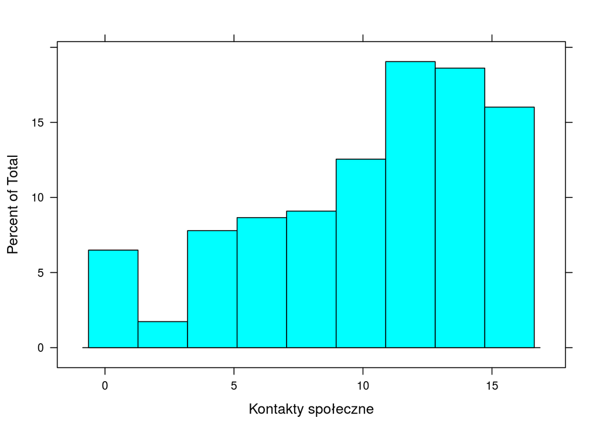

```r
soccont = apply(D.kdiff, 1, sum)
histogram(soccont, xlab="Kontakty społeczne")
```

Jest on o wiele bardziej symetryczny niż rozkład pierwszej wersji skali:

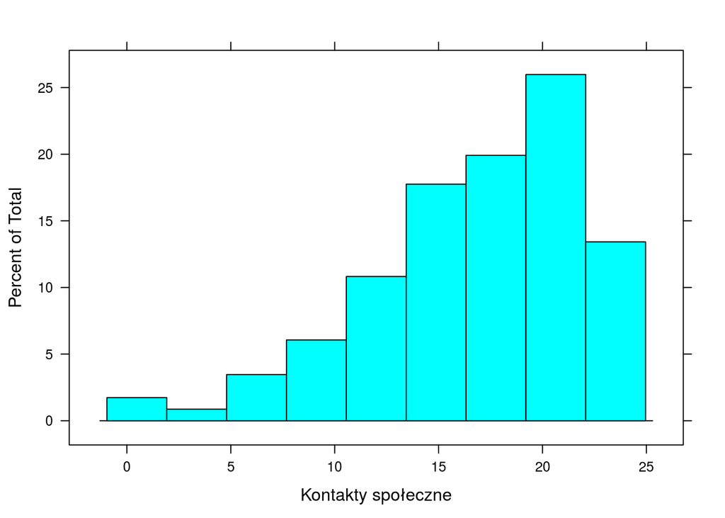

```r
histogram(~ soccont, data=D10, xlab="Kontakty społeczne")
```

Dlatego też nowe wersje skali zostaną użyte w dalszych analizach. Jest to podyktowane przede wszystkim tym, że będą one użyte w analizach opartych na współczynnikach korelacji, a jak wiadomo ucięte rozkłady i ograniczenia wariancji zmiennych bardzo silnie zaniżają ich wartości.

**Koniec raporty**